# Species metadata description

# Biodiversity mapping

The following pdf gives a description of the data used in the pipeline run that corresponds to the folder this document resides in. It should be used as a guide for anyone who wants to know more about the data used in the corresponding outputs (maps and datasets) and/or would like to replicate the data.

We begin with basic information about the pipeline run.

| Characteristic | Value |
| --- | --- |
| Date | 2024-01-24 |
| Taxa | amphibiansReptiles, spiders, bugs, caddislflies, dragonflies, fungi, lichens |
| Region type | county |
| Region code | 50 |
| Total species | 6023 |
| Total datasets used | 30 |
| DOI | 10.15468/dl.y76f2f |

In addition to the above, data was downloaded with a maximum uncertainty regarding coordinates of 100 metres.

| taxa | species | redListedSpecies |
| --- | --- | --- |
| amphibiansReptiles | 14 | 0 |
| bugs | 313 | 0 |
| caddislflies | 181 | 0 |
| dragonflies | 43 | 0 |
| fungi | 3973 | 54 |
| lichens | 995 | 69 |
| spiders | 504 | 3 |

| dsName | dataType | observations | redListedObservations |
| --- | --- | --- | --- |
| Freshwater benthic invertebrates ecological collection NTNU University Museum | PA | 3534769 | 0 |
| Lichen field notes, Oslo (O) | PA | 107602 | 3886 |
| Fungi field notes, Oslo (O) | PA | 74920 | 408 |
| Norwegian Species Observation Service | PO | 62119 | 1884 |
| Terrestrial and limnic invertebrates systematic collection, NTNU University Museum | PO | 14071 | 49 |
| Red list project inventory, lichens | PA | 13860 | 9250 |
| Lichen herbarium TRH, NTNU University Museum | PO | 12086 | 905 |
| Lichen herbarium, Oslo (O) UiO | PO | 5308 | 450 |
| Fungarium, Oslo (O) UiO | PO | 4629 | 336 |
| Mycology herbarium TRH, NTNU University Museum | PO | 4292 | 140 |

The following gives species richness for observations across the surveyed region by taxa.

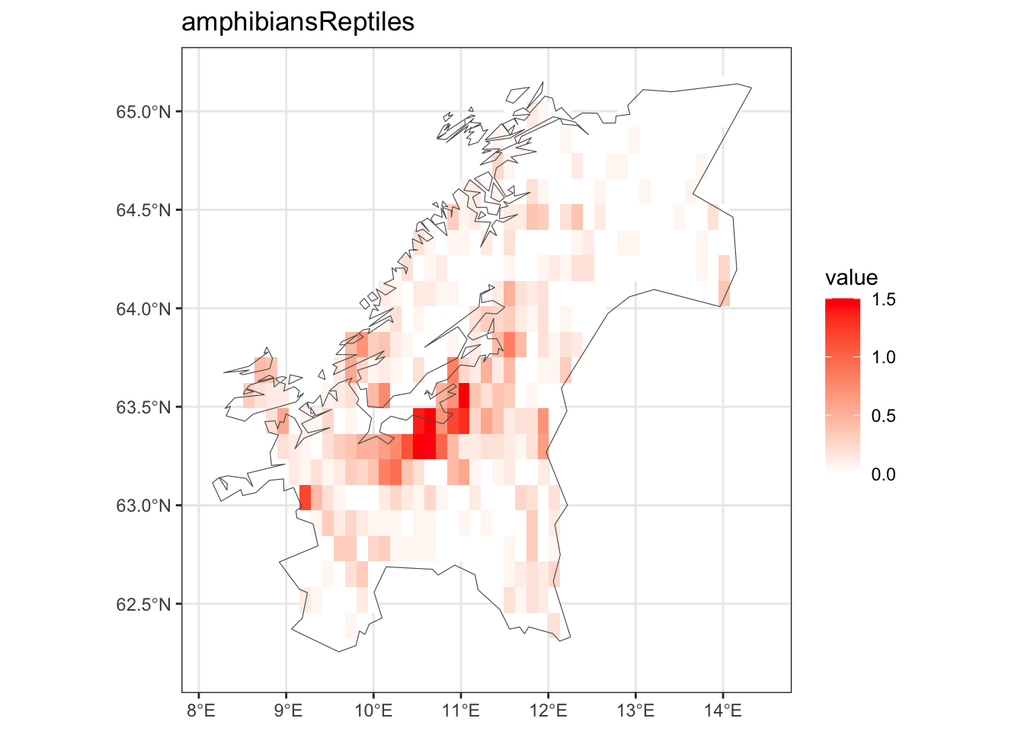

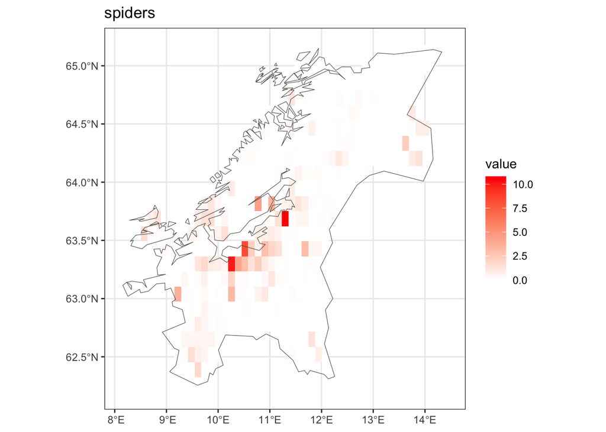

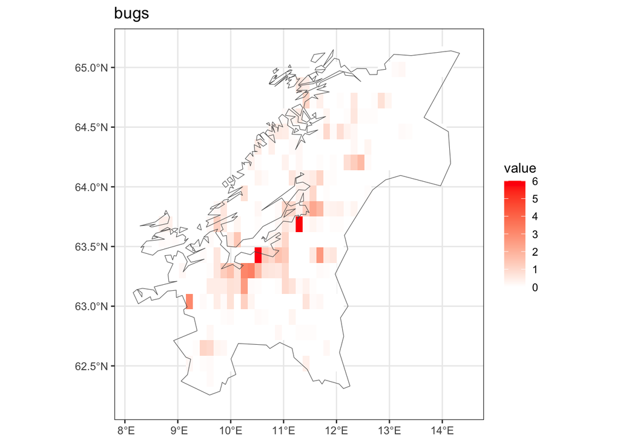

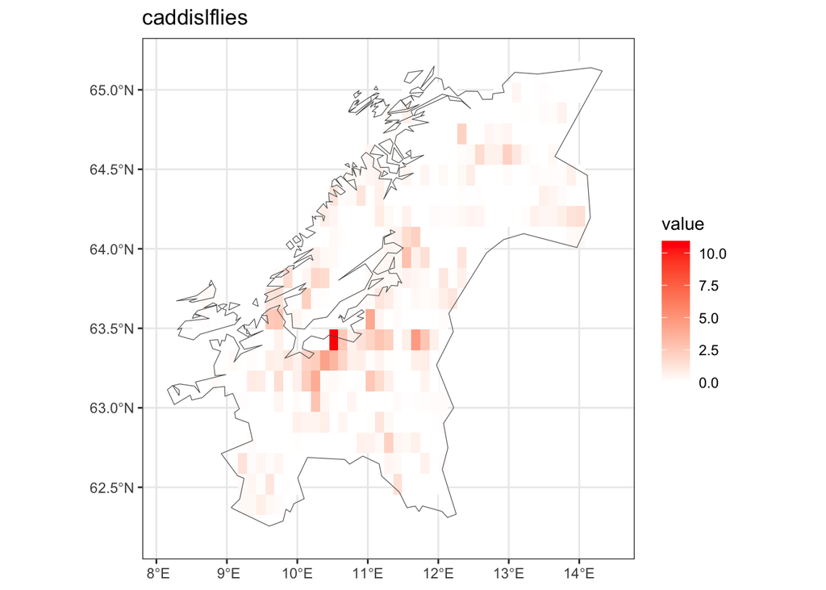

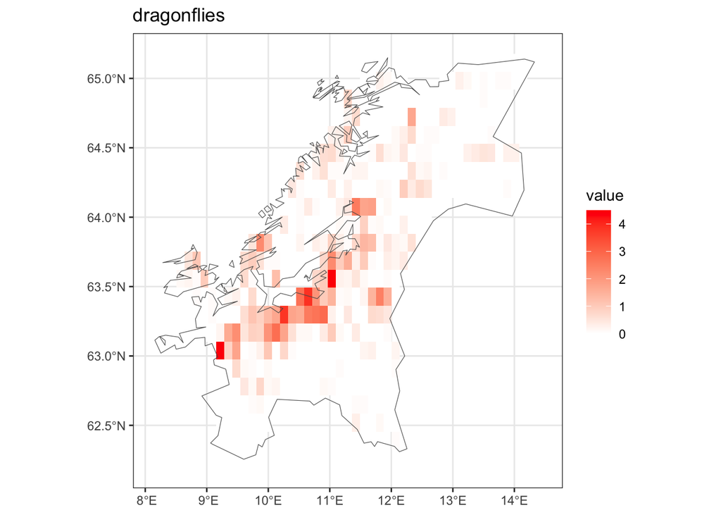

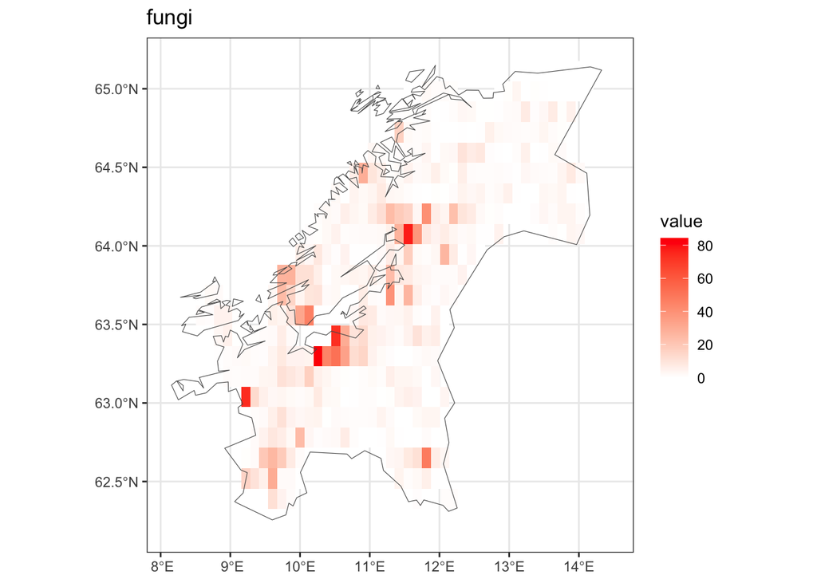

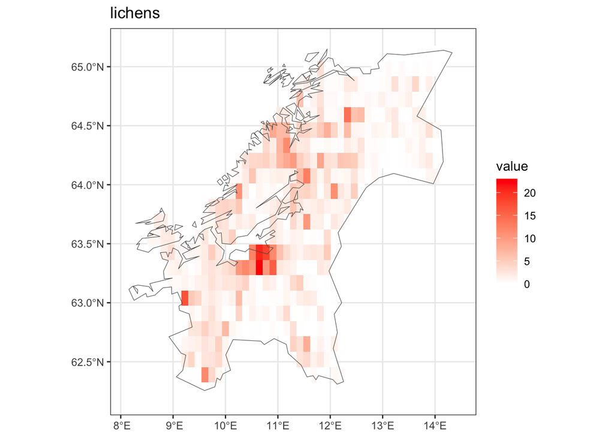

The following gives spatial density for observations across the surveyed region by taxa.

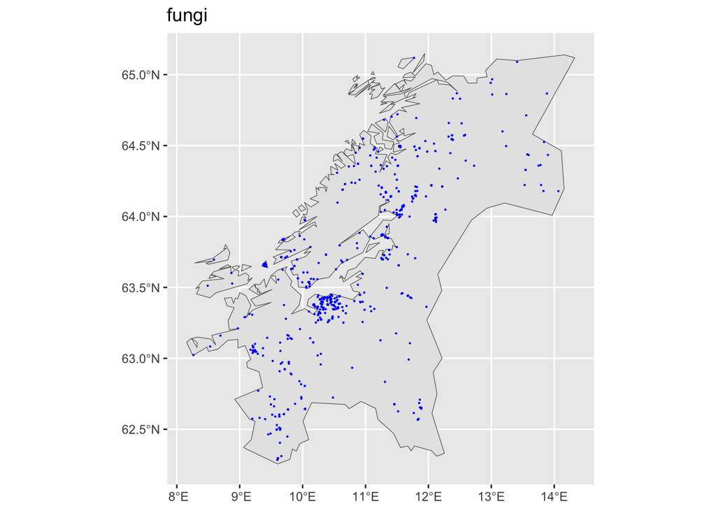

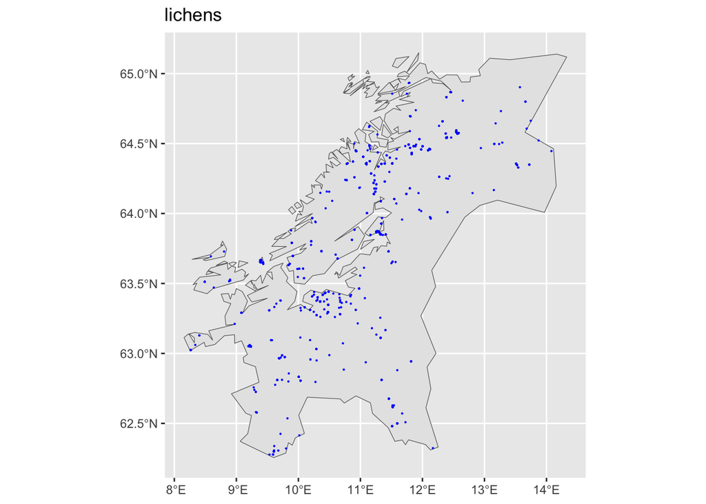

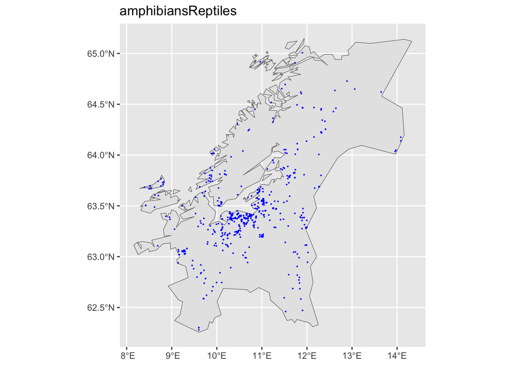

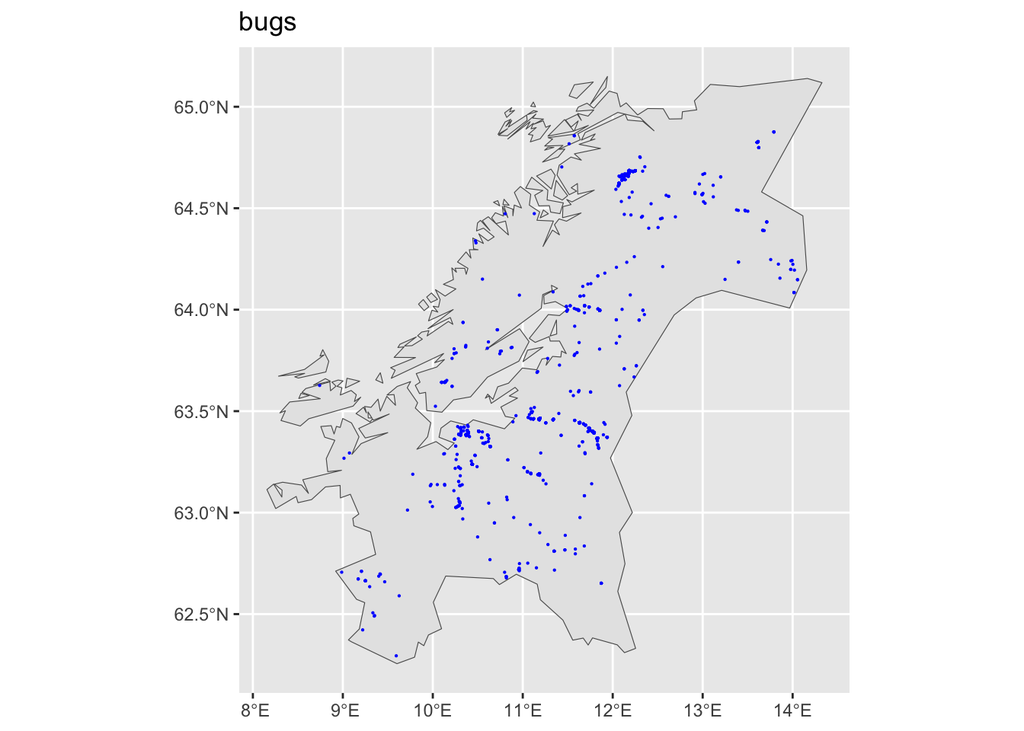

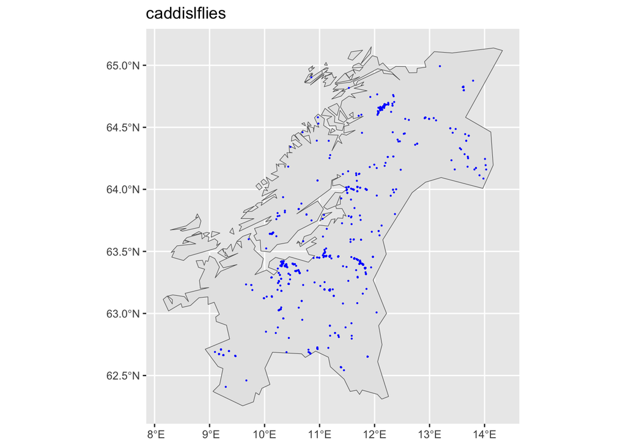

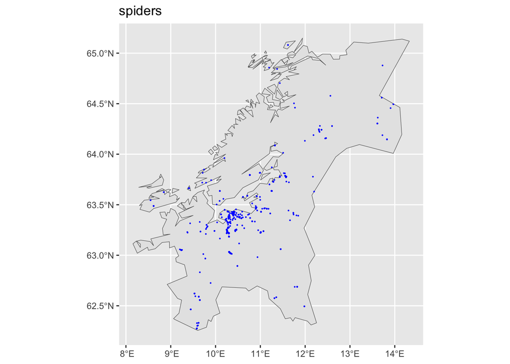

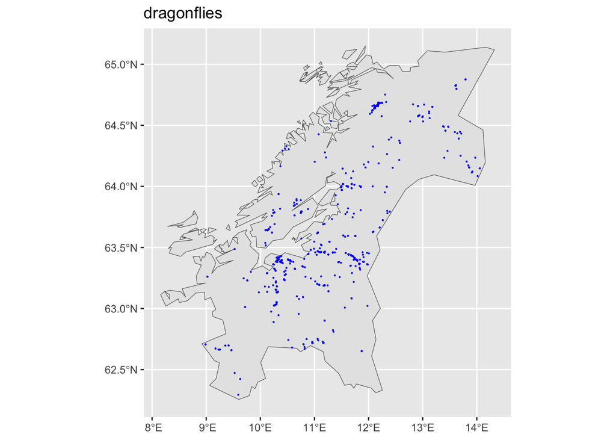

## Appendices

### Appendix 1

The tables below give further information on the observations used for our pipeline run.

Total numbers of observations used in pipeline run for each dataset by taxa.

| taxa | dsName | Observations |
| --- | --- | --- |
| amphibiansReptiles | Herpetile collection NTNU University Museum | 1699 |
| amphibiansReptiles | Norwegian Species Observation Service | 1512 |
| amphibiansReptiles | Norwegian Biodiversity Information Centre - Other datasets | 289 |
| amphibiansReptiles | Reptilia notes, NTNU University Museum | 49 |
| amphibiansReptiles | iNaturalist Research-grade Observations | 19 |
| amphibiansReptiles | Observation.org, Nature data from around the World | 6 |
| amphibiansReptiles | Jordal | 1 |
| bugs | Freshwater benthic invertebrates ecological collection NTNU University Museum | 598620 |
| bugs | Terrestrial and limnic invertebrates systematic collection, NTNU University Museum | 3138 |
| bugs | National insect monitoring in Norway | 1786 |
| bugs | Norwegian Species Observation Service | 1291 |
| bugs | Entomology, Oslo (O) UiO | 129 |
| bugs | iNaturalist Research-grade Observations | 20 |
| bugs | NINA insect database | 4 |
| bugs | Collection of various insect orders, Natural History Museum, University of Oslo | 2 |
| bugs | naturgucker | 2 |
| bugs | Observation.org, Nature data from around the World | 1 |
| caddislflies | Freshwater benthic invertebrates ecological collection NTNU University Museum | 2337713 |
| caddislflies | Terrestrial and limnic invertebrates systematic collection, NTNU University Museum | 4268 |
| caddislflies | Norwegian Species Observation Service | 632 |
| caddislflies | National insect monitoring in Norway | 342 |
| caddislflies | Entomology, Oslo (O) UiO | 44 |
| caddislflies | Artportalen (Swedish Species Observation System) | 5 |
| caddislflies | Entomology collection, UiT Tromsø Museum | 1 |
| dragonflies | Freshwater benthic invertebrates ecological collection NTNU University Museum | 598436 |
| dragonflies | Norwegian Species Observation Service | 2838 |
| dragonflies | Terrestrial and limnic invertebrates systematic collection, NTNU University Museum | 976 |
| dragonflies | iNaturalist Research-grade Observations | 40 |
| dragonflies | Observation.org, Nature data from around the World | 26 |
| dragonflies | naturgucker | 1 |
| fungi | Fungi field notes, Oslo (O) | 74767 |
| fungi | Norwegian Species Observation Service | 40027 |
| fungi | Lichen field notes, Oslo (O) | 15678 |
| fungi | Lichen herbarium TRH, NTNU University Museum | 5228 |
| fungi | Fungarium, Oslo (O) UiO | 4621 |
| fungi | Mycology herbarium TRH, NTNU University Museum | 4289 |
| fungi | Jordal | 2855 |
| fungi | Lichen herbarium, Oslo (O) UiO | 1980 |
| fungi | Notes from the Mycology Herbarium, Oslo (O) | 594 |
| fungi | Red list project inventory, lichens | 490 |
| fungi | Norwegian specimens stored in Herb. Klepsland (pre 2022) | 271 |
| fungi | iNaturalist Research-grade Observations | 254 |
| fungi | Lichen herbarium, UiB | 176 |
| fungi | Artportalen (Swedish Species Observation System) | 128 |
| fungi | Observation.org, Nature data from around the World | 53 |
| fungi | Lichen herbarium, The Arctic University Museum of Norway (TROM) | 14 |
| fungi | Lichen herbarium, NMBU | 12 |
| fungi | naturgucker | 8 |
| fungi | Ecofact | 3 |
| lichens | Lichen field notes, Oslo (O) | 91924 |
| lichens | Norwegian Species Observation Service | 13677 |
| lichens | Red list project inventory, lichens | 13370 |
| lichens | Lichen herbarium TRH, NTNU University Museum | 6858 |
| lichens | Lichen herbarium, Oslo (O) UiO | 3328 |
| lichens | iNaturalist Research-grade Observations | 447 |
| lichens | Norwegian specimens stored in Herb. Klepsland (pre 2022) | 313 |
| lichens | Lichen herbarium, UiB | 256 |
| lichens | Artportalen (Swedish Species Observation System) | 169 |
| lichens | Fungi field notes, Oslo (O) | 153 |
| lichens | Jordal | 45 |
| lichens | Lichen herbarium, The Arctic University Museum of Norway (TROM) | 33 |
| lichens | Lichen herbarium, NMBU | 19 |
| lichens | Ecofact | 10 |
| lichens | Fungarium, Oslo (O) UiO | 8 |
| lichens | Observation.org, Nature data from around the World | 6 |
| lichens | Mycology herbarium TRH, NTNU University Museum | 3 |
| lichens | Notes from the Mycology Herbarium, Oslo (O) | 1 |
| spiders | Terrestrial and limnic invertebrates systematic collection, NTNU University Museum | 5689 |
| spiders | NINA insect database | 3420 |
| spiders | Norwegian Species Observation Service | 2142 |
| spiders | National insect monitoring in Norway | 999 |
| spiders | Entomological collections, UiB | 149 |
| spiders | iNaturalist Research-grade Observations | 44 |
| spiders | Artportalen (Swedish Species Observation System) | 1 |

Total numbers of observations used in pipeline run for each data type by taxa.

| taxa | dataType | Observations |
| --- | --- | --- |
| amphibiansReptiles | PO | 3575 |
| bugs | PA | 598620 |
| bugs | PO | 4587 |
| bugs | Counts | 1786 |
| caddislflies | PA | 2337713 |
| caddislflies | PO | 4950 |
| caddislflies | Counts | 342 |
| dragonflies | PA | 598436 |
| dragonflies | PO | 3881 |
| fungi | PA | 90935 |
| fungi | PO | 60513 |
| lichens | PA | 105447 |
| lichens | PO | 25173 |
| spiders | PO | 11445 |
| spiders | Counts | 999 |